# MCMC II

James M. Flegal

## Agenda

- Markov chain Monte Carlo, again
- Gibbs sampling
- Output analysis for MCMC
- Convergence diagnostics
- Examples: Capture-recapture and toy example

## Gibbs Sampling

1. Select starting values $x_0$ and set $t=0$
2. Generate in turn (deterministic scan Gibbs sampler)
   - $x^{(1)}_{t+1} \sim f( x^{(1)} | x^{(-1)}_t)$
   - $x^{(2)}_{t+1} \sim f( x^{(2)} | x^{(1)}_{t+1}, x^{(3)}_t, \dots, x^{(p)}_t)$
   - $x^{(3)}_{t+1} \sim f( x^{(3)} | x^{(1)}_{t+1}, x^{(2)}_{t+1}, x^{(4)}_t, \dots, x^{(p)}_t)$
   - …
   - $x^{(p)}_{t+1} \sim f( x^{(p)} | x^{(-p)}_{t+1})$
3. Increment $t$ and go to Step 2

## Gibbs Sampling

- Common to have one or more components not available in closed form
- Then one can just use a MH sampler for those components known as a Metropolis within Gibbs or Hybrid Gibbs sampling
- Common to ``block'' groups of random variables

## Example: Capture-recapture

- Data from a fur seal pup capture-recapture study for $i=7$ census attempts
- Goal is to estimate the number of pups in a fur seal colony using a capture-recapture study

| Count | Parameter | 1 | 2 | 3 | 4 | 5 | 6 | 7 |
| --- | --- | --- | --- | --- | --- | --- | --- | --- |
| Captured | $c_i$ | 30 | 22 | 29 | 26 | 31 | 32 | 35 |
| Newly Caught | $m_i$ | 30 | 8 | 17 | 7 | 9 | 8 | 5 |

## Example: Capture-recapture

- Let $N$ be the population size, $I$ be the number of census attempts where $c_i$ were captured ($I=7$ in our case), and $r$ be the total number captured ($r = \sum_{i=1}^I m_i = 84$)
- We consider a separate unknown capture probability for each census $(\alpha_1, \dots, \alpha_I)$ where the animals are equally ``catchable''
- Then

  $$L(N,\alpha | c,r) \propto \frac{N!}{(N-r)!} \prod_{i=1}^{I} \alpha_i ^{c_i} (1-\alpha_i) ^ {N-c_i}$$

## Example: Capture-recapture

- Assume $N$ and $\alpha$ are apriori independent with
  $$f(N) \propto 1 \mbox{ and } f(\alpha_i | \theta_1, \theta_2) \stackrel{i.i.d.}{\sim} \mbox{Beta} (\theta_1, \theta_2)$$
- We use $\theta_1 = \theta_2 = 1/2$, which is the Jeffrey's Prior
- The resulting posterior is proper when $I>2$ and recommended when $I>5$

## Example: Capture-recapture

- Then it is easy to show the posterior is
  $$f(N,\alpha | c,r) \propto \frac{N!}{(N-r)!} \prod_{i=1}^{I} \alpha_i ^{c_i} (1-\alpha_i) ^ {N-c_i} \prod_{i=1}^{I} \alpha_i^{-1/2} (1-\alpha_i)^{-1/2} .$$
- Further, one can show
  $$\begin{aligned}
  N - 84 | \alpha & \sim \mbox{NB} \left( 85, 1 - \prod_{i=1}^{I} (1-\alpha_i) \right) \mbox{ and }\\
  \alpha_i | N & \sim \mbox{Beta} \left( c_i + 1/2 , N -c_i + 1/2 \right) \mbox{ for all }i
  \end{aligned}$$

## Example: Capture-recapture

Then we can consider the chain

$$\left(N , \alpha\right) \rightarrow \left(N' , \alpha\right) \rightarrow \left(N' , \alpha'\right)$$
or
$$\left(N , \alpha\right) \rightarrow \left(N , \alpha'\right) \rightarrow \left(N' , \alpha'\right) ,$$
where both involve a ``block'' update of $\alpha$

## Example: Capture-recapture

First, we can write the data into R

```r
captured <- c(30, 22, 29, 26, 31, 32, 35)
new.captures <- c(30, 8, 17, 7, 9, 8, 5)
total.r <- sum(new.captures)
```

## Example: Capture-recapture

The following R code implements the Gibbs sampler

```r
gibbs.chain <- function(n, N.start = 94, alpha.start = rep(.5,7)) {
    output <- matrix(0, nrow=n, ncol=8)
    for(i in 1:n){
        neg.binom.prob <- 1 - prod(1-alpha.start)
        N.new <- rnbinom(1, 85, neg.binom.prob) + total.r
        beta1 <- captured + .5
        beta2 <- N.new - captured + .5
        alpha.new <- rbeta(7, beta1, beta2)
        output[i,] <- c(N.new, alpha.new)
        N.start <- N.new
        alpha.start <- alpha.new
    }
    return(output)
}
```

## MCMC output analysis

How can we tell if the chain is mixing well?

- Trace plots or time-series plots
- Autocorrelation plots
- Plot of estimate versus Markov chain sample size
- Effective sample size (ESS)
  $$\text{ESS} (n) = \frac{n}{1+2 \sum_{k=1}^{\infty} \rho_{k}(g)},$$
  where $\rho_{k}(g)$ is the autocorrelation of lag $k$ for $g$
- Alternative, ESS can be written as
  $$\text{ESS} (n) = \frac{n}{\sigma ^2 / \text{Var} g}$$
  where $\sigma ^2$ is the asymptotic variance from a Markov chain CLT

## Example: Capture-recapture

Then we consider some preliminary simulations to ensure the chain is mixing well

```r
trial <- gibbs.chain(1000)
plot.ts(trial[,1], main = "Trace Plot for N")
for(i in 1:7){
    plot.ts(trial[,(i+1)], main = paste("Alpha", i))
    }

acf(trial[,1], main = "Lag Plot for N")
for(i in 1:7){
    acf(trial[,(i+1)], main = paste("Lag Alpha", i))
    }
```

## Example: Capture-recapture

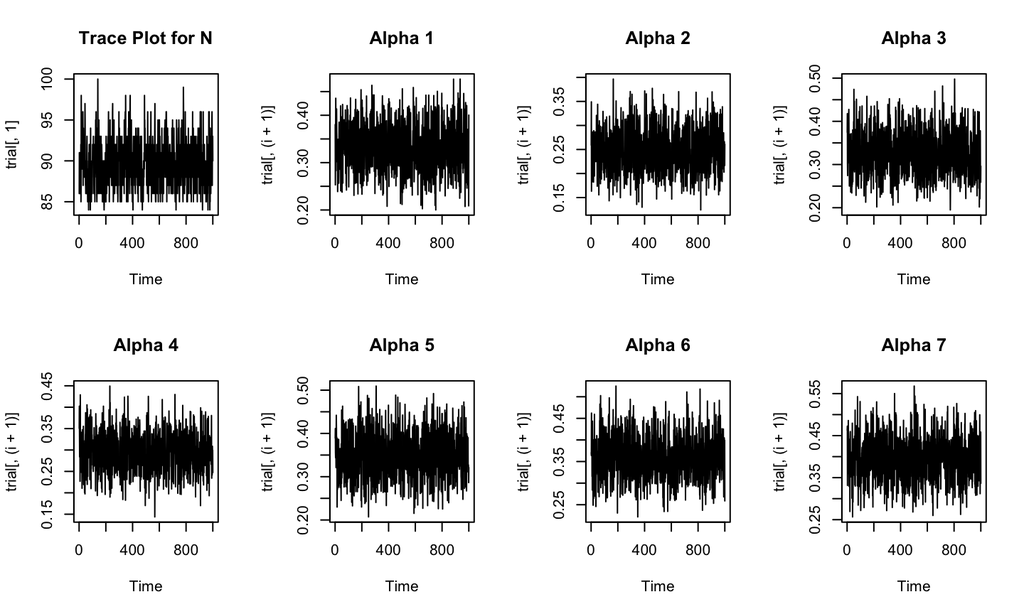

## Example: Capture-recapture

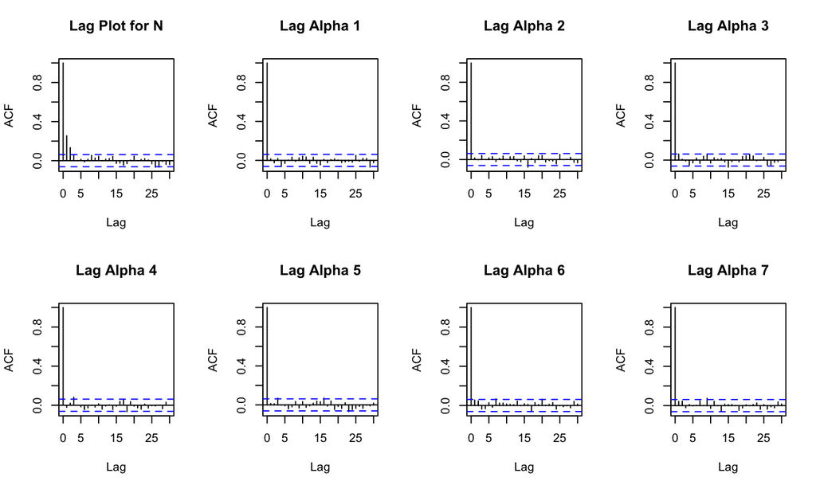

## Example: Capture-recapture

Now for a more complete simulation to estimate posterior means and a 90% Bayesian credible region

```r
sim <- gibbs.chain(10000)
N <- sim[,1]
alpha1 <- sim[,2]
```

## Example: Capture-recapture

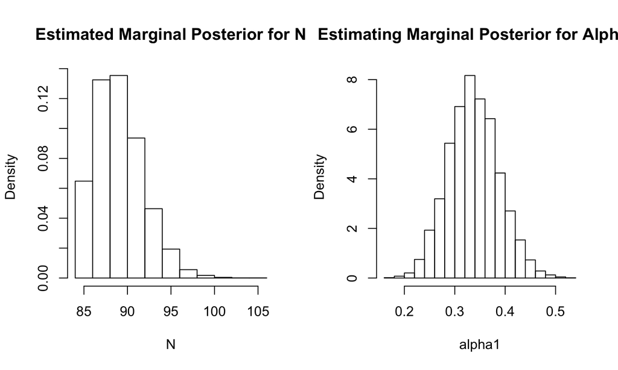

```r
par(mfrow=c(1,2))
hist(N, freq=F, main="Estimated Marginal Posterior for N")
hist(alpha1, freq=F, main ="Estimating Marginal Posterior for Alpha 1")
```

```r
par(mfrow=c(1,1))
```

## Example: Capture-recapture

```r
library(mcmcse)
ess(N)
```

```
##       se
## 8421.642
```

```r
ess(alpha1)
```

```
##       se
## 8519.459
```

## Example: Capture-recapture

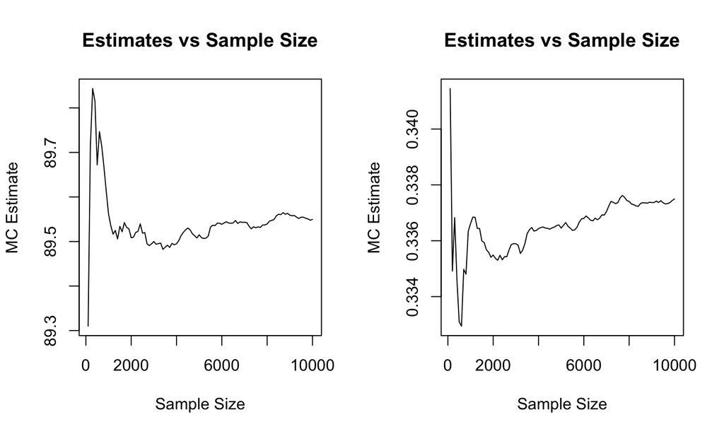

```r
par(mfrow=c(1,2))
estvssamp(N)
estvssamp(alpha1)
```

```r
par(mfrow=c(1,1))
```

## Example: Capture-recapture

```r
mcse(N)
```

```
## $est
## [1] 89.5495
##
## $se
## [1] 0.0307835
```

```r
mcse.q(N, .05)
```

```
## $est
## [1] 86
##
## $se
## [1] 0.02930293
```

```r
mcse.q(N, .95)
```

```
## $est
## [1] 95
##
## $se
## [1] 0.06565672
```

## Example: Capture-recapture

```r
mcse(alpha1)
```

```
## $est
## [1] 0.3374951
##
## $se
## [1] 0.0005427247
```

```r
mcse.q(alpha1, .05)
```

```
## $est
## [1] 0.2556669
##
## $se
## [1] 0.0009743541
```

```r
mcse.q(alpha1, .95)
```

```
## $est
## [1] 0.4221397
##
## $se
## [1] 0.001015246
```

## Example: Capture-recapture

```r
current <- sim[10000,] # start from here is you need more simulations
sim <- rbind(sim, gibbs.chain(10000, N.start = current[1], alpha.start = current[2:8]))
N.big <- sim[,1]
```

## Example: Capture-recapture

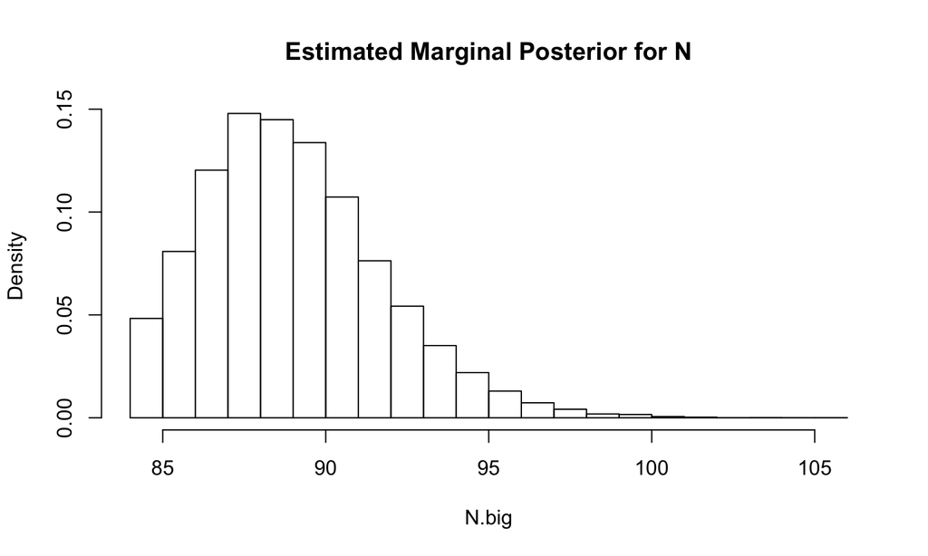

```r
hist(N.big, freq=F, main="Estimated Marginal Posterior for N")
```

## Example: Capture-recapture

```r
ess(N)
```

```
##       se
## 8421.642
```

```r
ess(N.big)
```

```
##       se
## 14446.78
```

## Example: Capture-recapture

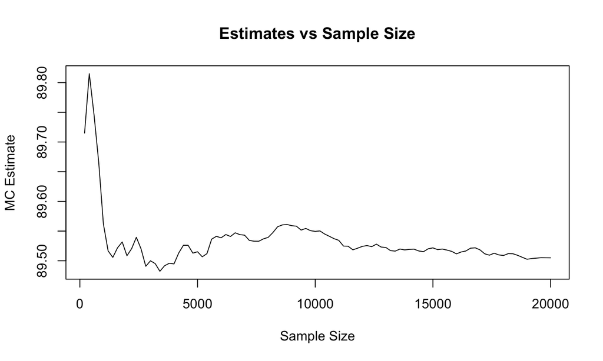

```r
estvssamp(N.big)
```

## Example: Capture-recapture

```r
mcse(N)
```

```
## $est
## [1] 89.5495
##
## $se
## [1] 0.0307835
```

```r
mcse(N.big)
```

```
## $est
## [1] 89.50495
##
## $se
## [1] 0.02318482
```

## Example: Capture-recapture

```r
mcse.q(N, .05)
```

```
## $est
## [1] 86
##
## $se
## [1] 0.02930293
```

```r
mcse.q(N.big, .05)
```

```
## $est
## [1] 86
##
## $se
## [1] 0.01798403
```

## Example: Capture-recapture

```r
mcse.q(N, .95)
```

```
## $est
## [1] 95
##
## $se
## [1] 0.06565672
```

```r
mcse.q(N.big, .95)
```

```
## $est
## [1] 95
##
## $se
## [1] 0.04391722
```

## Convergence diagnostics

- A more popular method of MCMC output analysis
- There are many; Gelman and Rubin diagnostic, Geweke's diagnostic, Heidel diagnostic, Raferty diagnostic, and other in `coda` package
- Useful to detect problem with a sampler, but offer *no* guarantee you have converged
- Think of these like hypothesis testing

## Gelman and Rubin diagnostic

Gelman and Rubin Diagnostic is also used a stopping criteria

- Most popular method for stopping the simulation, one of many convergence diagnostics
- Simulates $m$ independent parallel Markov chains
- Considers a ratio of two different estimates of $\text{Var}_{\pi} g$, not $\sigma_{g}^{2}$ from the CLT
- Argue the simulation should continue until the diagnostic ($\widehat{R}_{0.975}$) is close to 1

## Toy example

- Let $Y_1,\dots,Y_m$ be i.i.d.Â $\mbox{N}(\mu,\lambda)$ and let the prior for $(\mu,\lambda)$ be proportional to $1/\sqrt{\lambda}$
- The posterior density is characterized by
  $$\pi(\mu,\lambda|y) \propto \lambda^{-\frac{m+1}{2}} \exp\left \{ -\frac{1}{2\lambda} \sum_{j=1}^m (y_j-\mu)^2 \right \}$$
  which is proper as long as $m \ge 3$

## Toy example

- A Gibbs sampler requires the full conditionals
  $$\mu|\lambda,y \sim \mbox{N} ({\bar y},\lambda/m)$$
  and
  $$\lambda | \mu, y \sim \mbox{IG}\left( \frac{m-1}{2},
  \frac{s^{2} + m(\bar{y}-\mu)^{2}}{2} \right) \; ,$$
  where ${\bar y}$ is the sample mean and $s^{2}=\sum (y_i - \bar{y})^{2}$

## Toy example

- Consider the Gibbs sampler that updates $\lambda$ then $\mu$
  $$(\lambda',\mu') \rightarrow (\lambda,\mu') \rightarrow (\lambda,\mu)$$
- This sampler is geometrically ergodic
- Suppose $m=11$, $\bar{y}=1$, and $s^{2}=14$
- Then $E(\mu | y)=1$ and $E(\lambda | y)=2$
- Consider estimating $E(\mu | y)$ and $E(\lambda | y)$ with $\bar{\mu}_{n}$ and $\bar{\lambda}_{n}$

## Toy example

Stopped the simulation when

$$\begin{matrix}
BM: & t_{.975, (a - 1)} \displaystyle \frac{ \hat{\sigma}_{BM} }{ \sqrt{n} } + I(n < 400) < 0.04 \\
& \\
GRD: & \hat{R}_{0.975} + I(n < 400) < 1.005
\end{matrix}$$
- 1000 independent replications + Starting from $\bar{y}$ for BM + Starting from draws from $\pi$ for GRD - Used 4 chains for GRD

## Toy example

[figure not shown]

Plots of $\bar{\mu}_{n}$ vs. $n$ for both stopping methods

## Toy example

| MSE | BM | GRD |
| --- | --- | --- |
| MSE for $E(\mu \| y)$ | 3.73e-05 (1.8e-06) | 0.000134 (9.2e-06) |
| MSE for $E(\lambda \| y)$ | 0.000393 (1.8e-05) | 0.00165 (0.00012) |

## Toy example

[figure not shown]

Histograms of $\bar{\mu}_{n}$ for both stopping methods.

## Summary

- Bayesian inference usually requires a MCMC simulation
- Metropolis-Hastings algorithm and Gibbs samplers
- Basic idea is similar to OMC, but sampling from a Markov chain yields **dependent** draws
- MCMC output analysis is often ignored or poorly understood